# Notebook

```python
%pylab inline
import skimage.io as skio
from IPython.display import Image
from skimage.segmentation import clear_border
from pyparty.tools.manager import ParticleManager
from pyparty import Canvas
```

```
/Users/Clay/Library/Enthought/Canopy_64bit/User/lib/python2.7/site-packages/skimage/filter/__init__.py:6: skimage_deprecation: The `skimage.filter` module has been renamed to `skimage.filters`.  This placeholder module will be removed in v0.13.
  warn(skimage_deprecation('The `skimage.filter` module has been renamed '
```

### **Automated Detection of Sickle Cells from Color Images of Red Blood Cells**

#### **Abstract:**

The goal of this project was to develop a method for automated detection of sickle cells from color images of blood samples independent of an image's magnification and color. Sickle cells are the result of a genetic disease called Sickle Cell Anemia. Currently, detection and monitoring of Sickle Cell Anemia is done manually by examining slides of blood samples. This project was an attempt to automate that process, or at least reduce the total number of cells that must be examined by removing cells from images that had been identified with a high degree of accuracy. First, a pipeline for automated image segmentation was developed in order to produce a binary image containing the 2D shapes of blood cells in the images for analysis and classification. Second, an attempt was made to develop a systematic means by which the 2D blood cell shapes could be classified into one of three groups: healthy cells lying flat, healthy cells lying on their sides, and sickle cells. A measure of circularity was used to differentiate healthy blood cells lying flat from healthy cells lying on their sides and sickle cells. However, issues stemming from incorrect watershedding prevented successful classification beyond this point. In order to improve upon the results presented in this paper, corrections should be made to the watershedding function so that cells in contact can be more accurately separated. This will then allow for a more effective implementation of cell classification.

#### **1.0 Introduction:**

Sickle Cell Anemia (SCA) is a blood disorder that affects the ability of hemoglobin in red blood cells to bind oxygen and deliver it throughout the body. It is an autosomal recessive genetic disorder that arises when an individual receives two recessive alleles for the disease. The recessive allele results in a single code letter change in the DNA that causes the production a valine in place of a glutamic acid in the beta-globin of the hemoglobin protein complex. This valine then enables the hemoglobin complexes to polymerize when they become deoxygenated. Polymerization of the hemoglobin complexes eventually stretches red blood cells into the characteristic "sickle" shape. It is this irregular shape that causes the symptoms associated with the disease. Because the disease is autosomal recessive, those who carry the disease produce both the mutated beta-globin and the healthy beta-globin. As such, carriers of the trait do not display the serious complications of those who have received two recessive forms of the allele.  
Sickle cells are more rigid and fragile than healthy blood cells. This causes them to rupture at a higher rate than healthy blood cells, which leads to a decrease in the total number of blood cells in the body. This reduced number of total blood cells coupled with their poor ability of transporting oxygen throughout the body results in fatigue. The cells irregular shape also leads to formation of aggregates of blood cells that block circulatory flow. This is both painful and causes tissue damage when a blockage lasts for extended periods of time. The culmination of these complications leads to a decreased life expectance in those affected by the disease.  
The disease is more prevalent among those with African heritage because it provides resistance to malaria, a parasitic disease that predominantly affects regions in Africa. The malaria parasite targets red blood cells and decreases their ability to bind oxygen. This causes rapid sickling of cells for those who have SCA or those who are carriers of the trait. These cells are then destroyed by the body's phagocytes, which also kill the parasite in these blood cells. Specifically, among those who are carriers of the trait, the parasitic blood cells are destroyed and the healthy, non-sickled blood cells remain in the circulation. This provides a survival advantage for carriers of the trait in the African regions where malaria is prominent. However, people with heritage from these regions where the trait is advantageous also have a significantly higher chance of receiving two recessive alleles for the trait resulting in SCA.  
Diagnosis of the disease usually occurs during the first year of one's life. Because the disease is most prevalent among those with African heritage, all African American babies are tested for the trait when they are born. If positive for the trait or disease, these individuals are monitored throughout their lives. Such monitoring requires blood samples to be examined under a microscopes to determine the extent of sickling in their blood cells. This project was undertaken in an attempt to make this process more efficient. It was hypothesized that the characteristic shape that is produced in sickle cells would allow for their detection through the use of various shape descriptors that could be applied to segmented images of the blood samples. This project attempts to identify 3 classes of red blood cells based on systematic qualities of their 2D shapes and are as follows; healthy blood cells lying flat, healthy blood cells lying on their sides, and sickle cells.

http://ghr.nlm.nih.gov/condition/sickle-cell-disease  
http://www.dnalc.org/resources/3d/17-sickle-cell.html

#### **2.0 Methods: Ilastik**

##### **2.1 Ilastik with Raw Image:**

This study began by attempting a machine learning approach to object classification through use of the image analysis program, Ilastik. This program offers multiple methods for interactive object classification. The user can then save the parameters for a particular classification and apply them to other images, thus allowing for batch processing. The first Ilastik project type tested was its object classification from pixel classification method. This method allows for the entire process of segmentation and classification of objects within Ilastik.  
An image was first uploaded to the pipeline for segmentation. Ilastik allows the user to separate objects in the image from the background by manually labeling a few regions of both. Based on characteristics of the pixels in the labeled regions, the program produces a segmented, binary image in which objects have been identified from the background. Next, several measurement features are selected as the basis for object classification in the image. In the test, 'pixel count' and 'region axes' were used, as they produced the best results. Using the segmented image, 5 objects of each class were then manually labeled to serve as the basis for Ilastik's Random Forest Classifier. Ilastik then classifies the remaining unlabeled objects in the image automatically.  
This method produced poor segmentation and classification results, and highlighted several significant problems that needed to be addressed. First, the program was unable to separate and correctly distinguish blood cells that were in contact with one or more other cells. Second, segmentation left some cells with empty holes in their centers. This is because the curvature of blood cells creates a glare that is similar in color to the white background of the images. During segmentation, pixels in these regions were so similar to pixels in the labeled background regions that they were incorrectly thresholded out of the 2D cell shape. Third, small non-cell particles that were similar in color to blood cells were included in the segmentation. Finally, the resulting pipeline was not scalable to images of different magnifications. Most of Ilastik's measurement features are size dependent, and thus saved parameters for this test did not produce the same classification results when the tested image had been doubled in size (The doubling of image size replicates effects of increasing the magnification when using a microscope. The cells do not change in shape, but only in size. As such, classification results should be the same for any magnification of the same image.)  
Below is an image of the classification results from this pipeline. Object labeling can be seen on the middle image. **Red** objects were labeled as healthy blood cells lying flat, **yellow** objects were labeled as healthy cells lying on their side, and **green** objects were labeled as sickle cells. Classification was so poor that no analysis was done on these results.

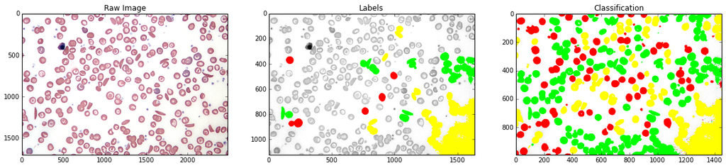

```python
worst = skio.imread('Worst.png')
worst_labeled = skio.imread('Worst_Labeled.png')
simple_big = skio.imread('simple_big.png')


f, (ax1, ax2, ax3) = plt.subplots(1,3, figsize=(20,24))
ax1.imshow(simple_big)
ax1.set_title('Raw Image')
ax2.imshow(worst_labeled)
ax2.set_title('Labels')
ax3.imshow(worst)
ax3.set_title('Classification')
```

##### **2.2 Ilastik with Fiji Segmentation:**

Due to the poor results of the first method, a second Ilastik pipeline was tested in an attempt to solve the problems related to poor segmentation. Accurate segmentation is crucial because without the correct production of 2D blood cell shapes, any classification based on cell shape cannot be completed. This second attempt utilized Ilastik's pipeline for object classification from a binary image. This pipeline allows the user to do a more specific image segmentation in an external program, and then upload the resulting binary image in parallel with the raw image for object classification, thus bypassing Ilastik's built in segmentation.  
The image analysis program Fiji was used in an attempt to correct the segmentation problems discussed in **2.1**. The segmentation done in Fiji was able to fill cell holes, remove non-cell particles, and separate cell cluster using a function called watershedding. The watershed function finds convex shaped objects in the image, and then separates them based on their convexity. After uploading the raw and binary image, the same measurement features were selected as in **2.1** to be used for object classification. Five cells of each class were labeled to serve as the basis for Ilastik’s machine learning classification. The remaining objects were then classified and the results have been displayed below. Again, **Red** objects were labeled as healthy blood cells lying flat, **yellow** objects were labeled as healthy cells lying on their side, and **green** objects were labeled as sickle cells.  
This method enabled much better segmentation of the images. Cell holes were correctly filled, small non-cell particles were removed from the image, and most bordering cells were correctly separated and identified as individual cells. However, classification was still inaccurate and the saved pipeline did not produce that same classification result when the image was doubled in size. These problems led to a new approach using written code to automate the process rather than using pre-existing object classification programs.

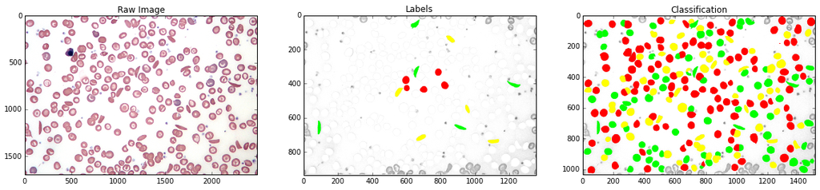

```python
bad = skio.imread('Bad.png')
Bad_Labeled = skio.imread('Bad_Labeled.png')

f, (ax1, ax2, ax3) = plt.subplots(1,3, figsize=(20,24))
ax1.imshow(simple_big)
ax1.set_title('Raw Image')
ax2.imshow(Bad_Labeled)
ax2.set_title('Labels')
ax3.imshow(bad)
ax3.set_title('Classification')
#do the counts
```

#### **3.0 Methods: Fiji, Scikit Image, and Pyparty**

##### **Introduction to the Problem**

Now that the goal was to develop a pipeline using code to automate the process, the problem was broken into two parts. The first focus was to create a systematic segmentation process that would work on all color images of red blood cells. The second focus was to develop a magnification independent method of classification based on an analysis of the segmented cell shapes.  
#####**3.1: Segmentation in Fiji**  
In **Section 2** Fiji produced the best segmentation results. Therefore, it was then used to experiment with segmentation techniques that could be replicated in the coded pipeline. The biggest problem faced during this stage was finding a method that would allow for accurate segmentation, independent of pixel color. It is difficult to create a systematic thresholding for RBG images because each pixel is a combination of several colors. Any variance in color between images makes it difficult to set of a specific range of cutoff values for each of the color channels that will produce consistent segmentation on images of varying color. Other color spaces were tested using Fiji in order to determine a means of segmentation that was independent of pixel color. The solution was found by converting images from RBG color space to YUV color space. The Y channel is for pixel brightness, while the U and V channels are for pixel color. Segmentation can be done using the YUV color space by setting a threshold range on the brightness (Y) channel and ignoring the U and V color channels. Based on results using Otsu Method of thresholding as tested in Fiji, the threshold cutoff of the Y channel in the pipeline was set to include pixels of the lowest brightness within the image. This segmentation process has been reproduced in this pipeline through use of the Python based image analysis tools provided by the Scikit Image application program interface (See **3.2** Below).

##### **3.2: Segmentation in Scikit Image**

As described above the YUV color space allows for segmentation based on a pixel brightness rather than pixel color. This segmentation is 4 step process. First, color images most be converted from their RBG color space, to the YUV color space. This conversion as no affect on the way an image looks, but changes the way in which pixel information is stored and can be accessed. Second, the Y, U, and V color channels must be labeled. This allows for operations to be performed on individual channels. Third, a histogram is plotted for pixel values for the Y, U, and V channels. The fourth step requires identifying the peak of interest in the histogram, and setting a threshold for segmentation based on this peak. The U and V channels on the histogram are the two color channels and are not considered for this method of segmentation. The Y channel is the channel of interest and produces the histogram on which a threshold value is set for pixel brightness. In the histogram below there is a small peak at 60 and a large peak at 100 (the x values in the histogram have been arbitrarily set, however this does not produce any problems because it is only the histogram shape that matters). The small peak is the one that includes the pixels that make up the red blood cells; therefore, the cells can be segmented from the image background by setting a threshold value to include this peak. This is done by setting 'y > threshold = 80' in the code below. Every pixel with a Y value above the threshold value is considered background and converted to a white pixel. Every pixel with a Y value equal to or less than 80 is considered to be part of an object of interest and converted to a black pixel. This allows for a segmentation independent of color that produces a binary image on which several post-processing steps can be run to produce the 2D shapes needed for cell classification.

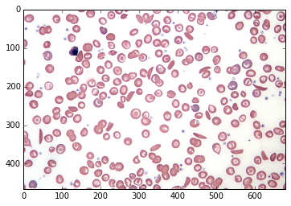

```python
#rcParams["figure.figsize"] = (12, 9) #<--- large default figures
rcParams['image.cmap'] = 'gray'  # change default colormap

rgb = skio.imread('simple_small.png')
rgb = rgb[:,:,0:3] #Drop 4th opacity color channel
REZ = rgb.shape[0:2]
imshow(rgb);
```

```python
import skimage.color as skcolor
luv = skcolor.rgb2luv(rgb)
```

**Step #2:** Label the channels.

```python
y = luv[:,:,0]
u = luv[:,:,1]
v = luv[:,:,2]
```

**Step #3:** Plot a histogram for each channel in YUV. The Y channel is **yellow**, the U channel is **blue**, and the V channel is **violet**. The channel of interest is the Y channel, which represents luminance (or brightness) of the image pixels. This is the best choice for segmentation because it allows for segmentation of pixels independent of their color combinations. The program is set to include the small peak in the yellow channel (pictured below at 60) by considering anything with brightness greater than 80, to be the background (and thus white in the resulting binary image).

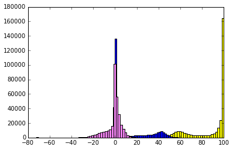

```python
plt.hist(y.ravel(), color='yellow', bins=50)
plt.hist(u.ravel(), color='blue', bins=50)
plt.hist(v.ravel(), color='violet', bins=50);
```

**Step #4:** The threshold value is set based on the small peak in the yellow histogram. As stated above this allows for segmentation independent of pixel color. **Note:** The segmentation is set at a default threshold for y>80. If an image shows the small yellow peak in the histogram outside of this range, the threshold value should be adjusted in the following cell to include the peak of interest by setting y greater that the rightmost point of the small peak in the yellow histogram.

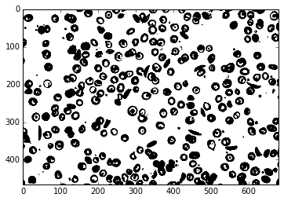

```python
threshold = 80
luv[y>threshold]
imshow (y>threshold)
```

Here is a visual example of each chanel in the YUV spectrum, compared with the RBG spectrum.  
http://1.bp.blogspot.com/_IkIY0TAOeVI/TTIIHFar8wI/AAAAAAAAABU/XqZLwDaM0uY/s1600/RGBYUVCOMP.jpg

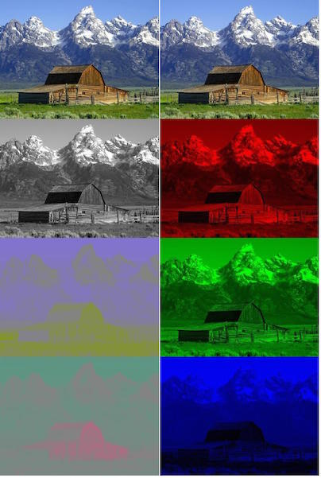

```python
yuv_barn = Image(filename='yuv.jpg')
yuv_barn
```

For more information on YUV segmentation, a screencast is presented below.

```python
from IPython.display import YouTubeVideo
YouTubeVideo("EzkKfm2TUn8")
```

[video not shown]

#####**3.3: Post-Processing in Scikit Image**  
Now that the cells have been separated from the background via color independent segmentation, the resulting binary image must undergo several post-processing steps to produce the 2D shapes necessary for classification.  
#####**3.3.1: Fill Holes and Remove Objects on the Edge**  
The first post-processing step fills the holes, by inverting regions of white pixels that are completely surrounded by regions of black pixels. The second post-processing step removes all black regions of pixels that are in contact with the edge of the picture by inverting the pixels in these regions to white. The result is displayed below.

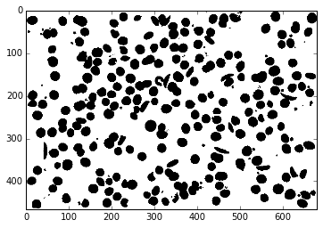

```python
from scipy.ndimage import binary_fill_holes
from skimage.segmentation import clear_border

binary = y > threshold
binary_filled = binary_fill_holes(np.invert(binary))
binary_filled = clear_border(binary_filled)
binary_filled_bp = np.invert(binary_filled)
imshow((binary_filled_bp));
```

#####**3.3.2: Labeling and watershedding**  
The image must undergo further post-processing to separate touching cells and to remove the small debris that were included during thresholding. In order to address both of these issues, the contiguous regions of black pixels must be labeled as objects. Essentially, this tells the program that these regions are actually objects rather than a collection of individual pixels. This allows proceeding operations to be performed on the objects in the image rather than on the pixels in the image. Then cells in contact with other cells can be separated via the watershed function. This function considers all of the labeled objects in the image and splits any that are convex in shape. Below is an image showing a before and after of a convex shape that has undergone watershedding.  
http://www.nature.com/srep/2012/120711/srep00503/images_article/srep00503-f6.jpg

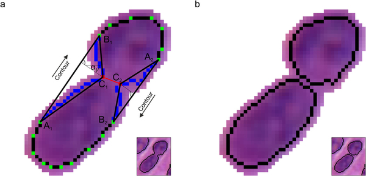

```python
convex = Image(filename='Convex_1.jpg')
convex
```

**Note:** The watershed function requires a binary image with white objects and black background. Therefore an inverted version of the image presented in **3.3.1** is used below by setting, 'image = binary_filled'.

```python
import skimage.morphology as morphology
from skimage.morphology import watershed
from skimage.feature import peak_local_max

image = binary_filled

# Now we want to separate the two objects in image
# Generate the markers as local maxima of the distance
# to the background

from scipy import ndimage
distance = ndimage.distance_transform_edt(image)
local_maxi = peak_local_max(distance, indices=False, footprint=np.ones((20, 20)), labels=image)
markers = morphology.label(local_maxi)
labels_ws = watershed(-distance, markers, mask=image)
```

```
/Users/Clay/Library/Enthought/Canopy_64bit/User/lib/python2.7/site-packages/skimage/measure/_label.py:4: skimage_deprecation: Call to deprecated function ``label``. Use ``skimage.measure.label`` instead.
  connectivity=None):
```

After the watershedding has been performed on the shapes in the image, the image is depicted below using the 'jet' color map. Each object in the image is a different color.

```
246
```

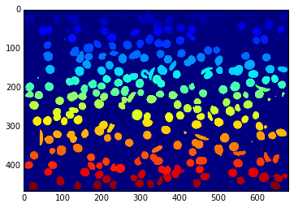

```python
from skimage.measure import regionprops
imshow(labels_ws, cmap = 'jet')
len(regionprops(labels_ws))
```

#####**3.4: Post-Processing in Pyparty** Now that the shapes in the image have been separated via watershedding, the image is sent to a second application program interface called Pyparty. Pyparty offers a collection of algorithms specifically designed for particle analysis and classification. This API is first used to complete the final post-processing step. Using Pyparty a scaling factor can be set for each image that is used to create a size range for shapes in the image that move forward to the classification phase. This allows for the removal of objects that fall outside the typical size range for blood cells in each individual image. Because this range is calculated for each image, it allows for the automated removal of non-blood cell objects in images independent of their magnification. The process is decribed in depth below.

First the image from **3.3.2** is uploaded to Pyparty. Each shape produced after watershedding is a different color and the background is white.

```
WARNING:pyparty.tools.manager:pmin < 10 may result in errors in some particle descriptors
```

```
Canvas (0x11c010d10):
   background  -->  (466 X 681) : file/colorstring/url
   particles   -->  246 particles : 1 types
   xygrid[300] -->  (20p X 15p) : (34.0 X 31.0) [pix/tile]
```

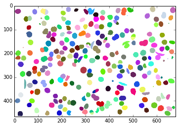

```python
from skimage.segmentation import clear_border
from pyparty.tools.manager import ParticleManager
from pyparty import Canvas


particles_identified_from_watershed = ParticleManager.from_labels(labels_ws)[1::]
sample_cells = Canvas(rez=REZ, background='white')
sample_cells.particles = particles_identified_from_watershed
sample_cells.show()
print sample_cells

sample_cells_unchanged = Canvas.copy(sample_cells)
```

#####**3.4.1: Setting a Scaling Factor for the Size of Objects to be Considered for Classification** Using Pyparty the non-blood cell particles are removed so that the only remaining shapes in the image will be red blood cells. While this could be done manually by setting cutoff values for object size, such an approach would not be applicable to images of differing magnification. In order to make sure this step will work for images of varying magnification the program calculates an average area based on healthy blood cells within the image. This average area is then used to set image-specific area range for objects that are to be considered in the classification.  
First, all shapes of high circularity (>0.9) are identified and separated from the other shapes in the image. All red blood cells are initially circular because the sickling of cells is a process that takes time. Thus, by selecting the highly circular particles in the image, an average area can be calculated based on the size of healthy red blood cells in the image. These shapes can be seen in the image below that is titled **'Shapes w/ Circularity > 0.9'**. In order to make sure that this calculation is not skewed due to small debris that are highly circular, a histogram of the areas for all shapes of circularity > 0.9 is created. From this histogram the first two bins (up to 40 particles) are always dropped so that small, highly circular debris will not be considered in the average area calculation. This histogram is displayed below and followed by an image in which the small debris contained in the first two bins of the histogram have been removed. The remaining shapes contained in this image titled **'Larger Shapes w/ Circularity > 0.9'**, are used to calculate the average size of healthy cells for each image. This serves as a scaling factor that is used to set an image specific upper and lower limit for the size of shapes that are considered for classification. This process is presented below.  
**Note:** The average area calculation does account for the presence of small and circular particles, but does not account for the presence of large and circular particles. This is because such particles are rarely seen in images of blood cells. A removal of objects in the upper most bin of the area histogram, usually results in the deletion of healthy blood cells rather than large non-blood cells.

```python
#Define functions to calculate circularity and the analytical value, (major axis)^2/area.
def major_div_area(majoraxis, area):
    return majoraxis**2 / area

def circularity(area, perimeter):
    return 4.0*pi*area / perimeter**2

majarea = major_div_area(sample_cells.major_axis_length, sample_cells.area)
circ = circularity(sample_cells.area, sample_cells.perimeter)
```

```python
area = sample_cells.area
circular_particles = sample_cells[(circ > 0.9) & (area > 20)]
circular_particles
```

```
<< 179 particles (['label_1']...['label_246']) / ptype="['nd_label']" at 0x11ac614d0 >>
```

The shapes from the original image with circularity greater than 0.9 and pixel area greater than 20 pixels are presented in the image below.

```
Canvas (0x11c010d10):
   background  -->  (466 X 681) : file/colorstring/url
   particles   -->  179 particles : 1 types
   xygrid[300] -->  (20p X 15p) : (34.0 X 31.0) [pix/tile]
```

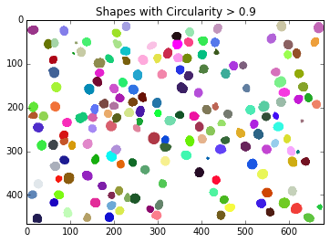

```python
sample_cells.particles = circular_particles
sample_cells.show(title= 'Shapes w/ Circularity > 0.9')
print sample_cells
```

The small non-cell particles must be removed from the from the average area classification. This is done by removing any shape from the above image that falls in the first two bins of the area histogram depicted below.

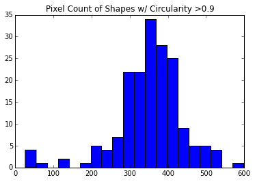

```python
counts, xbins, _ = plt.hist( circular_particles.area, bins=20)
plt.title('Pixel Count of Shapes w/ Circularity >0.9 ')
# Drop first two bins
minarea = xbins[2]
sample_cells.particles = sample_cells[circular_particles.area > xbins[2]]
```

The image below depicts all circular shapes from the above image that are **not** in the first two bins of the area histogram. It is from these shapes that the average area is calculated as the scaling factor that will be used to define the area range of shapes to be included in the classification for each image.

```
Canvas (0x1196369b0):
   background  -->  (466 X 681) : file/colorstring/url
   particles   -->  174 particles : 1 types
   xygrid[300] -->  (20p X 15p) : (34.0 X 31.0) [pix/tile]
```

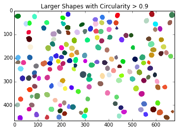

```python
sample_cells.show(title = 'Larger Shapes w/ Circularity > 0.9')
print sample_cells
```

```python
area_mean = np.mean(sample_cells.area)
```

After the average area is calculated the program is set to include all objects within the image that range from 20% of the average area to 180% of the average area. These values were determined by looking at data from several images and should include the shapes of interest for classification.

```
Canvas (0x1220d8110):
   background  -->  (466 X 681) : ndarray
   particles   -->  231 particles : 1 types
   xygrid[300] -->  (20p X 15p) : (34.0 X 31.0) [pix/tile]
Canvas (0x119ba6530):
   background  -->  (466 X 681) : ndarray
   particles   -->  15 particles : 1 types
   xygrid[300] -->  (20p X 15p) : (34.0 X 31.0) [pix/tile]
```

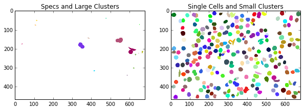

```python
area = sample_cells_unchanged.area
#removes very small cells or very big cells
maskout = (area < 0.2*area_mean) | (area > 1.8*area_mean)
#keeps cells between the defined range
maskin = (area > 0.2*area_mean) & (area < 1.8*area_mean)
bad_particles = sample_cells_unchanged[maskout]
good_particles = sample_cells_unchanged[maskin]

f, (ax1, ax2) = plt.subplots(1,2, figsize=(10,12))

sample_cells.particles = bad_particles
sample_cells.show(ax1, title='Specs and Large Clusters')
bad_cells = Canvas.copy(sample_cells)

sample_cells.particles = good_particles
sample_cells.show(ax2, title='Single Cells and Small Clusters')
good_cells = Canvas.copy(sample_cells)

print good_cells
print bad_cells
```

#####**3.5: Classification in Pyparty** After segmentation and post-processing, the remaining shapes in the images are now ready for classification. As mentioned above, goal of this project was to identify 3 classes of blood cells; healthy blood cells lying flat, healthy blood cells lying on their sides, and sickle cells. Healthy blood cells lying flat can be identified by shape circularity:  
$Circularity = (4*pi*Area)/Perimeter^2$  
This function produces a value ranging from 0 to 1 and thus is independent of shape size (image magnification). Classification based on this measurement has been set to consider all shapes with circularity above 0.85 as a healthy blood cells lying flat. This threshold value was determined experimentally through examination of large sets of data.  
After the healthy cells are identified using the circularity classification, the remaining cells are left to be classified as either healthy cells lying on their sides or as sickle cells. As depicted in the image below, it was hypothesized that healthy cells on their sides would have a shorter major axis length than the sickle cells that had ben stretched due to hemoglobin polymerization. It was also hypothesized that the area of sickle cells would be close to half that of healthy blood cells on their sides. It was then assumed that squaring the major axis length of the shape and dividing by its area would provide a dimensionless quantity that could effectively differentiate between healthy cells on the sides and sickle cells because the quantity should be significantly larger for sickle cells.  
$(MajorAxis^2)/Area$

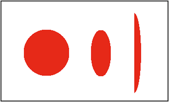

```python
rbc_paint = Image(filename='class_sample.png')
rbc_paint
```

#### **4.0 Results:**

##### **4.1: Segmentation and Post Processing**

The goal for segmentation in this pipeline was to develop an automated means of producing a segmentation from images of blood samples independent of the image color. The goal for post-processing was to develop an automated system of steps that could be applied to the segmented image in order to correctly produce the 2D blood cell shapes needed for classification, independent of the image magnification. This pipeline does this successfully up to the step of watershedding. The watershedding functions for both Fiji and Scikit Image present similar systematic errors. Both tend to cut in half healthy cells lying on their sides, have difficulty in separating healthy cells in contact with sickle cells, and to a lesser degree have difficulty in separating healthy cells lying flat in contact with other healthy cells lying flat. Interestingly, Fiji's watershed function produces far fewer errors than does Scikit Image on the same images. During the project the Scikit development team was asked why these errors were happening at a higher frequency when using their algorithms. They responded saying that the issue stems from problems related to their 'peak_local_max' function that is part of the watershedding process. Solving such a problem went beyond the scope of this project, but if corrected can be implemented in this pipeline in order achieve more accurate segmentation results.  
Further, it was noticed that different sized images tend to have more or less of these systematic errors. In an attempt to discover any trends the arise when watershedding is done of images of different sizes, the image above was watershed in both Scikit Image and Fiji at sizes of one half of the original size, the original size, and four times the original size. The results are presented below. **False positives** arise when cells were incorrectly cut in half, and **false negatives** arise when touching cells are incorrectly left as a cluster. For example, a single cell incorrectly cut in half results in a false positive, and a group of three touching cells that are not separated at all results in two false negatives. As presented in the table below, the larger the image the more false positives result from watershedding, and the smaller the image the more false negatives result from watershedding in both Scikit Image and Fiji.

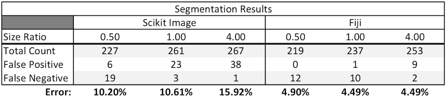

```python
seg_data_2 = Image(filename='seg_res.png')
seg_data_2
```

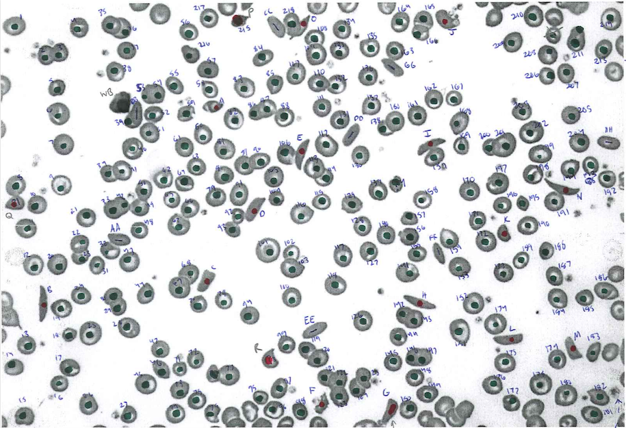

```python
man_lab = Image(filename='man_lab_2.png')
man_lab
```

#####**4.2.1: Classification in Ilastik:** The results for Ilastik's machine learning pipeline for object classification from a binary image are presented below. Of the 243 shapes produced using Fiji for the segmentation and post-processing, Ilastik classified 107 shapes as healthy cells lying flat, 62 shapes as healthy cells lying on their side, and 74 shapes as sickle cells.

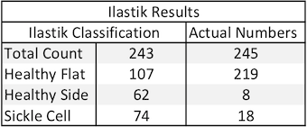

```python
ilastik_class = Image(filename='ilastik_class.png')
ilastik_class
```

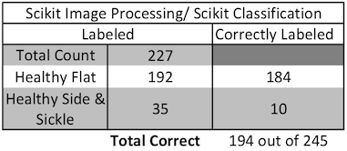

```python
sci_class_res = Image(filename='sci_class_res.png')
sci_class_res
```

#####**4.2.3: Classification of Fiji/Pipeline** Shown above in **4.1**, the watershedding done in Fiji produced the fewest total errors on the original and larger image (11 errors in each). As such, the original sized image was used to quantify the classification results for the images that had been watershed in Fiji. The classification results for this image are presented below. It is important to note that watershedding done in Fiji produces fewer errors during post-processing than does Scikit Image. This allows for a higher degree of accuracy in classification.

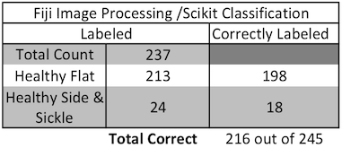

```python
fi_class_res = Image(filename='fi_class_res.png')
fi_class_res
```

#### **5.0 Conclusion:**

Overall, the project was successful in developing an automated segmentation process for blood samples independent of the image color. Only the watershedding function produced significant errors during the post-processing steps. Correcting the watershed function went beyond the scope of this research, but should be addressed by researchers attempting to improve accuracy classification results. A temporary fix that could be implemented in a program similar to this, is to run Fiji in "headless mode" for the watershedding step. Essentially, this would allow the program to send an the image to Fiji for watershedding step without actually opening the Fiji application window, and then export this watershed image back to the program. This was actually attempted using the standard method for running an application in "headless mode"; however, the Fiji application does not install like standard applications and thus a more complex approach must be developed in order to run the program "headlessly".  
The numbers for the classification results can be misleading. It is important to note that on this particular image a very small number of the classification errors resulted from the circularity classification. Most errors were the result of incorrect watershedding. In several instances cells in contact were not separated, or were incorrectly separated, thus producing the incorrect 2D shapes for classification. Secondly, healthy cells lying on there sides were cut in half over 50% of the time. These errors also resulted in the incorrect removal of several cells due to the size threshold set by the scaling factor in **3.4.1**. Because some cell clusters were not correctly separated during watershedding, the program identified their 2D shape as being above the cell size threshold, and they were thus incorrectly removed before the classification process. These problems made it difficult to implement classification beyond the first circularity division. It is important to note that the best classification results require the very accurate watershedding to correctly separate all of the cells in images. Any error that results from watershedding will produce subsequent errors in classification.  
While this project was unable to provide a highly accurate method for classification, a similar program to the one presented could still be used to make the process of examining blood samples more efficient. If a classification system were developed to classify at least some of the cells in images with a high degree of certainty, then these cells could be removed from the image so that an examiner would only have to look at the remaining questionable cells in the image.

```python
# Change the notebook style/layout
# Much thanks to those who created it!
from IPython.core.display import HTML
import urllib2
HTML(urllib2.urlopen('http://bit.ly/1Bf5Hft').read())
```